# Basics of R Programming Language

## Building a Basic Plot

The construction of ggplot graphics is incremental, allowing for the addition of new elements in layers. This approach grants users extensive flexibility and customisation options, enabling the creation of tailored plots to suit specific needs.

[figure not shown]

To build a ggplot, the following basic templates can be used for different types of plots.

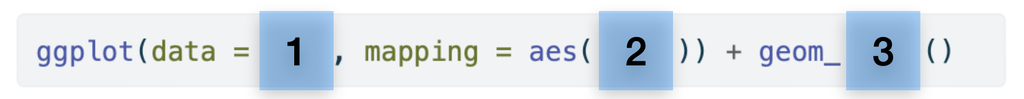

Three things are required for a ggplot:

### 1. The data

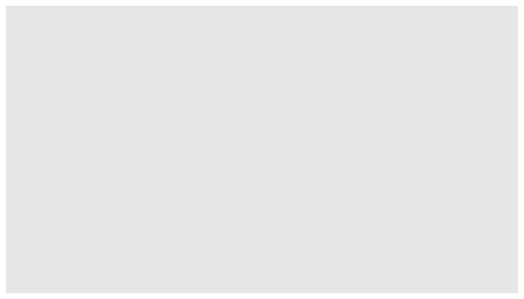

```r
# render plot background
ggplot(immuno_dataset$redcap_data$demographics)
```

This command results in an empty gray panel. We must specify how various columns of the data frame should be depicted in the plot.

### 2. Aesthetics `aes()`

Next, we specify the columns in the data we want to map to visual properties (called aesthetics or `aes` in ggplot2). e.g. the columns for x values, y values and colours.

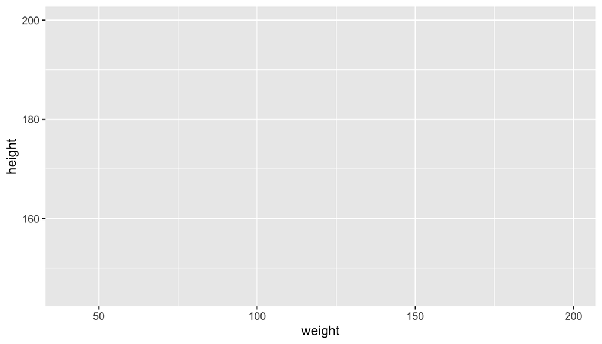

```r
ggplot(immuno_dataset$redcap_data$demographics, aes(x = weight, y = height))
```

This results in a plot which includes the grid lines, the variables and the scales for x and y axes. However, the plot is empty or lacks data points.

### 3. Geometric Representation `geom_()`

Finally, we specify the type of plot (the *geom*). There are different types of geoms:

`geom_blank()` draws an **empty plot**.

`geom_segment()` draws a **straight line**. `geom_vline()` draws a **vertical line** and `geom_hline()` draws a **horizontal line**.

`geom_curve()` draws a **curved line**.

`geom_line()/geom_path()` makes a **line plot**. `geom_line()` connects points from left to right and `geom_path()` connects points in the order they appear in the data.

`geom_point()` produces a **scatterplot**.

`geom_jitter()` adds a small amount of **random noise** to the points in a scatter plot.

`geom_dotplot()` produces a **dot plot**.

`geom_smooth()` adds a **smooth trend line to a plot**.

`geom_quantile()` draws **fitted quantile with lines** (a scatter plot with regressed quantiles).

`geom_density()` creates a **density plot**.

`geom_histogram()` produces a **histogram**.

`geom_bar()` makes a **bar chart**. Height of the bar is proportional to the number of cases in each group.

`geom_col()` makes a **bar chart**. Height of the bar is proportional to the values in data.

`geom_boxplot()` produces a **box plot**.

`geom_violin()` creates a **violin plot**.

`geom_ribbon()` produces a **ribbon** (y interval defined line).

`geom_area()` draws an **area plot**, which is a line plot filled to the y-axis (filled lines).

`geom_rect()`, `geom_tile()` and `geom_raster()` draw **rectangles**.

`geom_polygon()` draws **polygons**, which are filled paths.

`geom_text()` adds **text** to a plot.

`geom_text()` adds **label** to a plot.

The range of geoms available in `ggplot2` can be obtained by navigating to the `ggplot2` package in the Packages tab pane in RStudio (bottom right-hand corner) and scrolling down the list of functions sorted alphabetically to the `geom_...` functions.

Since we are interested in creating a scatter plot, the geometric representation of the data will be in point form. Therefore we use the `geom_point()` function.

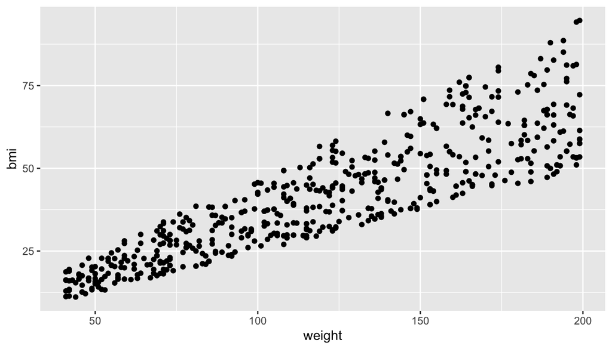

```r
ggplot(immuno_dataset$redcap_data$demographics, aes(x = weight, y = bmi)) +
  geom_point()
```

Notice that we use the `+` sign to add a *layer* of points to the plot. This concept bears resemblance to Adobe Photoshop, where layers of images can be rearranged and edited independently. In ggplot, each layer is added over the plot in accordance with its position in the code using the `+` sign.

**A note about `|>` and `+`**

`ggplot2` package was developed prior to the introduction of the pipe operator. In ggplot2, the `+` sign functions analogously to the pipe operator in other tidyverse functions, enabling code to be written from left to right.

## Customising Plots

### Adding Colour

The above plot could be made more informative. For instance, the additional information regarding the gender (i.e., `sex` column) could be incorporated into the plot. To do this, we can utilise `aes()` and specify which column in the data frame should be represented as the color of the points.

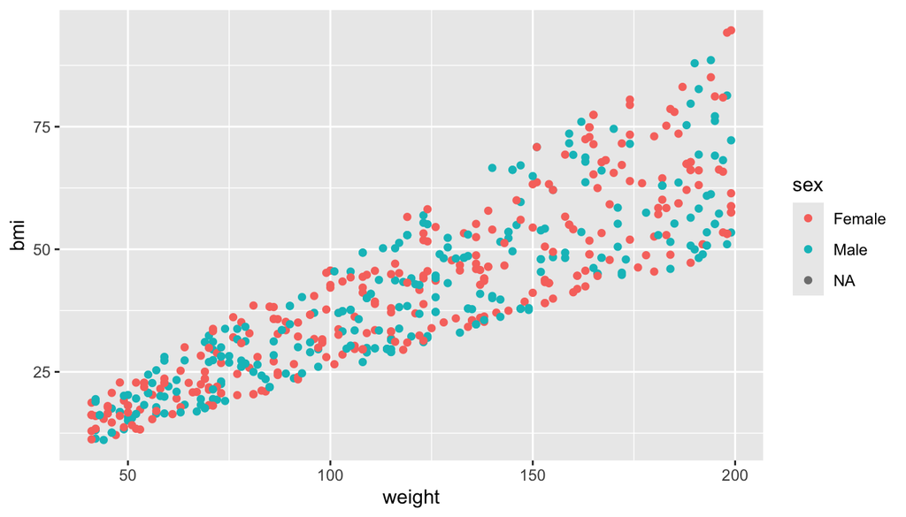

```r
ggplot(immuno_dataset$redcap_data$demographics, aes(x = weight, y = bmi, color = sex)) +
  geom_point()
```

To colour points based on a continuous variable, for example: height:

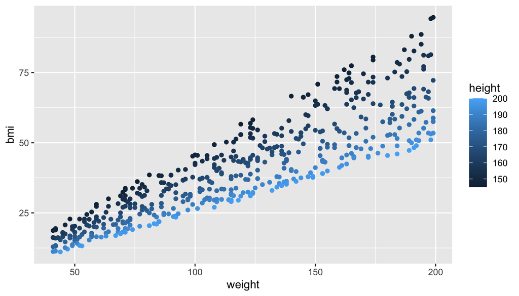

```r
ggplot(immuno_dataset$redcap_data$demographics, aes(x = weight, y = bmi)) +
  geom_point(aes(colour = height))
```

In `ggplot2`, a color scale is used for continuous variables, while discrete or categorical values are represented using discrete colors.

Note that some patient samples lack values, leading `ggplot2` to remove those points with missing values for `bmi` and `weight`.

### Adding Shape

Let’s add shape to points.

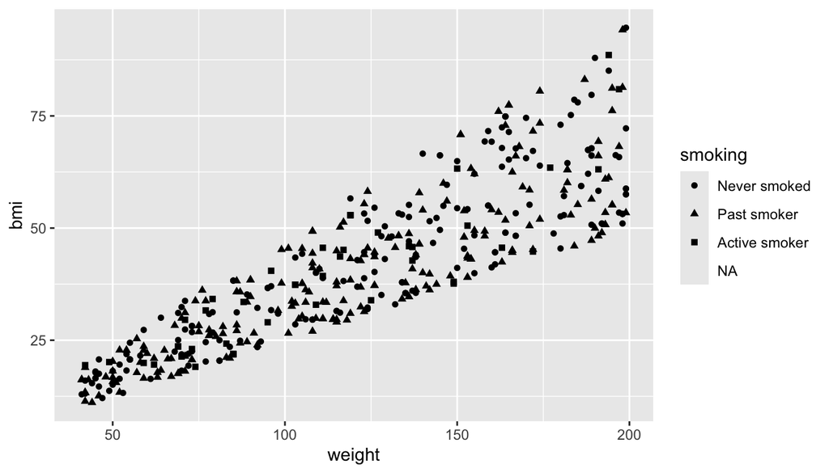

```r
ggplot(immuno_dataset$redcap_data$demographics, aes(x = weight, y = bmi)) +
  geom_point(aes(shape = smoking))
```

Note that some patient samples have not been classified and ggplot has removed those points with missing values for the smoking categories.

Some aesthetics like shape can only be used with categorical variables:

```r
ggplot(immuno_dataset$redcap_data$demographics, aes(x = weight, y = bmi)) +
  geom_point(aes(shape = height))
```

```
Error in `geom_point()`:
! Problem while computing aesthetics.
ℹ Error occurred in the 1st layer.
Caused by error in `scale_f()`:
! A continuous variable cannot be mapped to the shape aesthetic.
ℹ Choose a different aesthetic or use `scale_shape_binned()`.
```

The shape argument allows you to customise the appearance of all data points by assigning an integer associated with predefined shapes shown below:

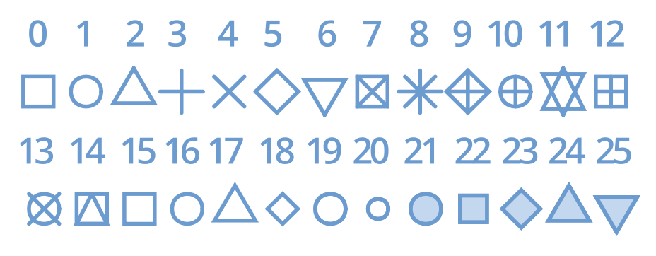

To use asterix instead of points in the plot:

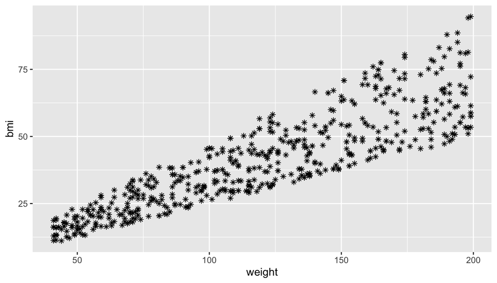

```r
ggplot(immuno_dataset$redcap_data$demographics, aes(x = weight, y = bmi)) +
  geom_point(shape = 8)
```

It would be useful to be able to change the shape of all the points. We can do so by setting the size to a single value rather than mapping it to one of the variables in the data set - this has to be done outside the aesthetic mappings (i.e. outside the `aes()` bit) as above.

**Aesthetic Setting vs. Mapping**

Instead of mapping an aesthetic property to a variable, you can set it to a single value by specifying it in the layer parameters (outside `aes()`). We map an aesthetic to a variable (e.g., `aes(shape = THREEGENE)`) or set it to a constant (e.g., `shape = 8`). If you want appearance to be governed by a variable in your data frame, put the specification inside `aes()`; if you want to override the default size or colour, put the value outside of `aes()`.

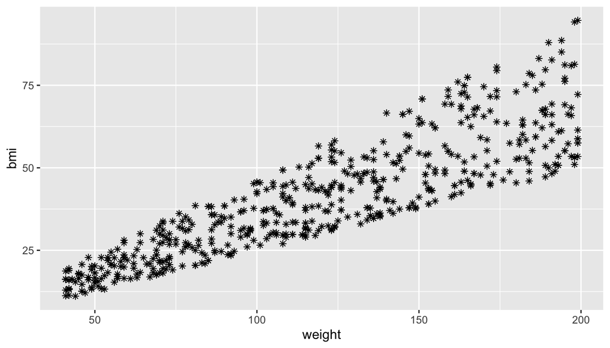

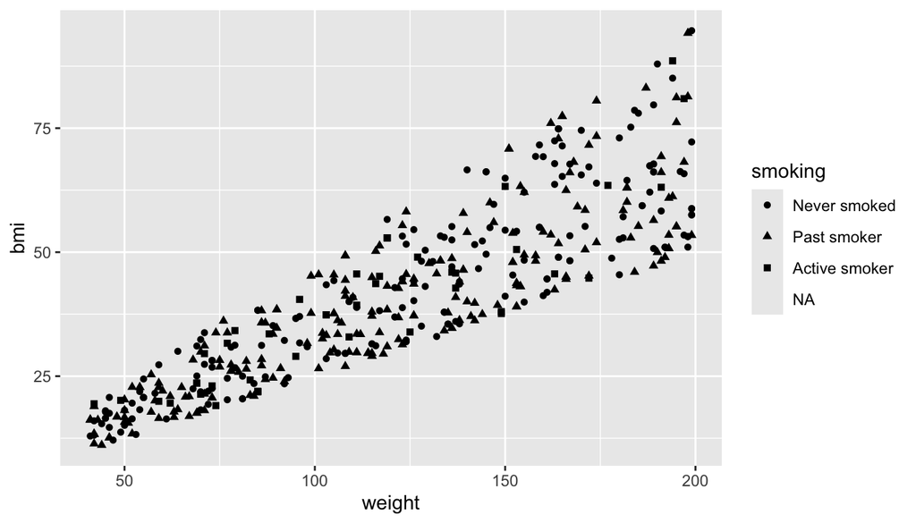

```r
# size outside aes()
ggplot(immuno_dataset$redcap_data$demographics, aes(x = weight, y = bmi)) +
  geom_point(shape = 8)
# size inside aes()
ggplot(immuno_dataset$redcap_data$demographics, aes(x = weight, y = bmi)) +
  geom_point(aes(shape = smoking))
```

It is usually preferable to use colours to distinguish between different categories but sometimes colour and shape are used together when we want to show which group a data point belongs to in two different categorical variables.

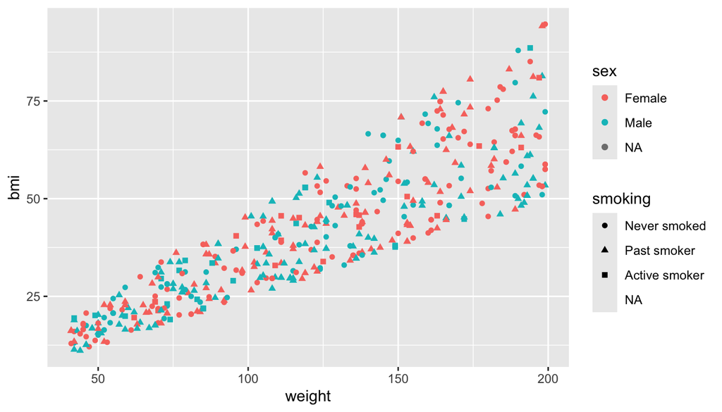

```r
ggplot(immuno_dataset$redcap_data$demographics, aes(x = weight, y = bmi)) +
  geom_point(aes(colour = sex, shape = smoking))
```

### Adding Size and Transparency

We can adjust the size and/or transparency of the points.

Let’s first increase the size of points.

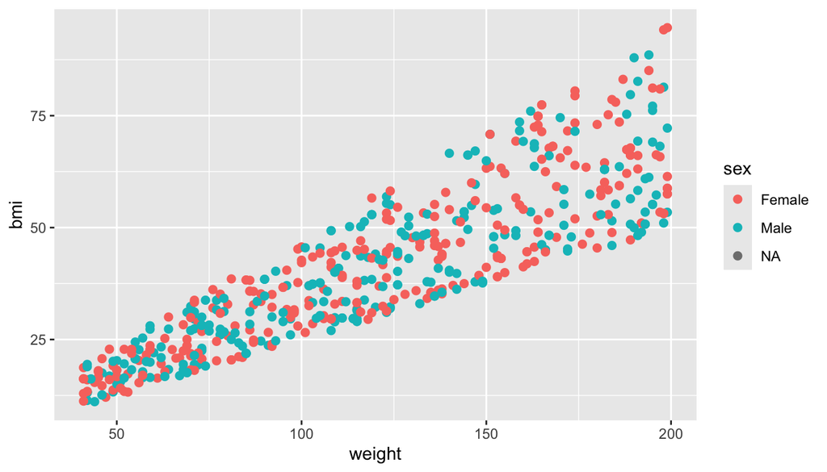

```r
ggplot(immuno_dataset$redcap_data$demographics, aes(x = weight, y = bmi)) +
  geom_point(aes(colour = sex), size = 2)
```

Note that here we add the size argument outside of the the aesthetic mapping.

Size is not usually a good aesthetic to map to a variable and hence is not advised.

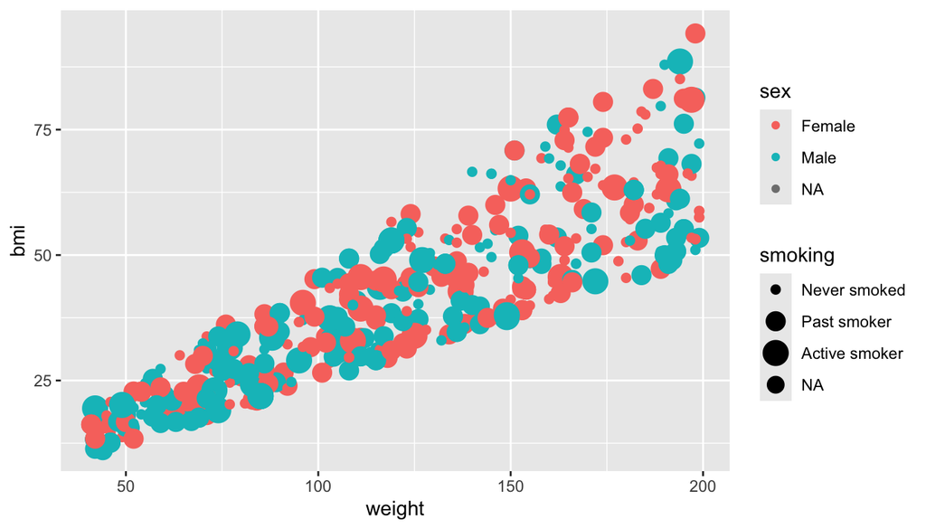

```r
ggplot(immuno_dataset$redcap_data$demographics, aes(x = weight, y = bmi)) +
  geom_point(aes(colour = sex, size = smoking))
```

Because this value is discrete, the default size scale uses evenly spaced sizes for points categorised on smoking categories.

Transparency can be useful when we have a large number of points as we can more easily tell when points are overlaid, but like size, it is not usually mapped to a variable and sits outside the `aes()`.

Let’s change the transparency of points.

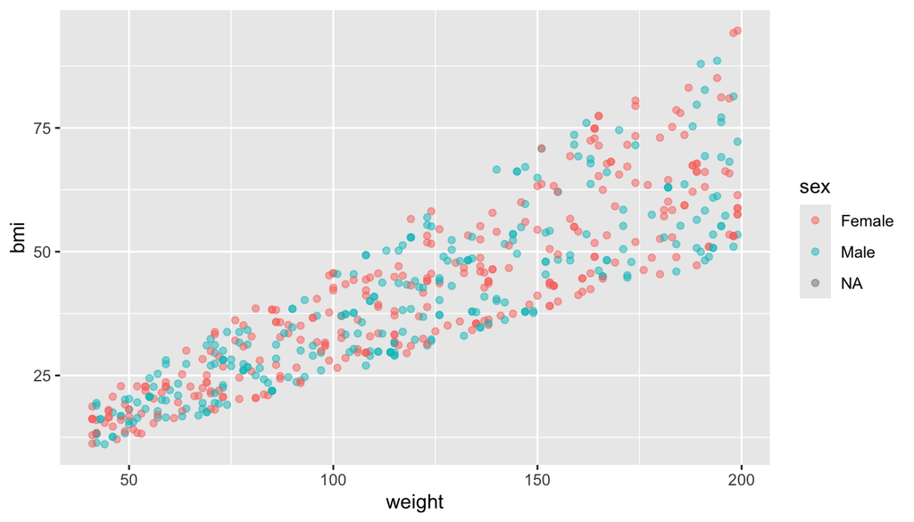

```r
ggplot(immuno_dataset$redcap_data$demographics, aes(x = weight, y = bmi)) +
  geom_point(aes(colour = sex), alpha = 0.5)
```

### Adding Layers

We can add another *layer* to this plot using a different geometric representation (or `geom_` function) we discussed previously.

Let’s add trend lines to this plot using the `geom_smooth()` function which provide a summary of the data.

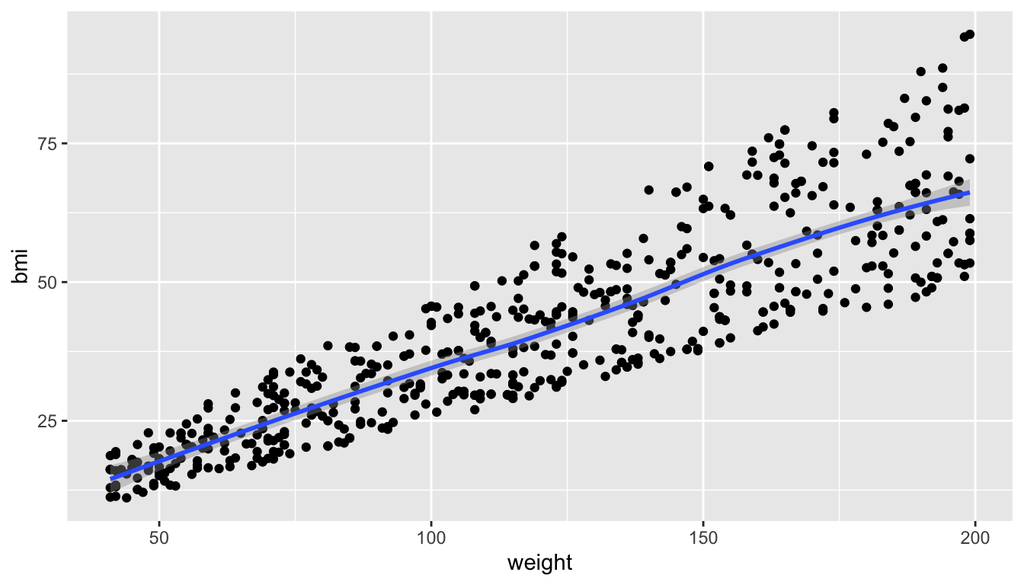

```r
ggplot(immuno_dataset$redcap_data$demographics) +
  geom_point(aes(x = weight, y = bmi)) +
  geom_smooth(aes(x = weight, y = bmi))
```

Note that the shaded area surrounding blue line represents the standard error bounds on the fitted model.

There is some annoying duplication of code used to create this plot. We’ve repeated the exact same aesthetic mapping for both geoms. We can avoid this by putting the mappings in the `ggplot()` function instead.

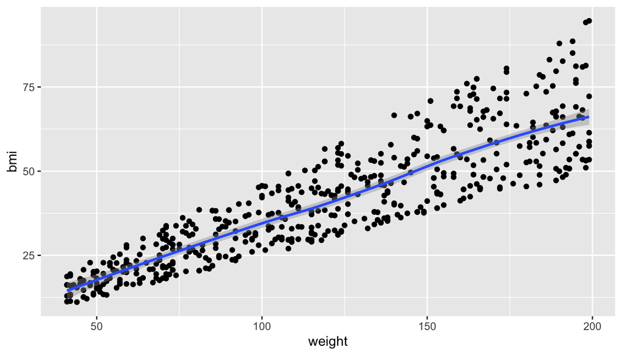

```r
ggplot(immuno_dataset$redcap_data$demographics, aes(x = weight, y = bmi)) +
  geom_point() +
  geom_smooth()
```

Geom layers specified earlier in the command are drawn first, preceding subsequent geom layers. The sequence of geom layers specified in the command determines their order of appearance in the plot.

If you switch the order of the `geom_point()` and `geom_smooth()` functions above, you’ll notice a change in the regression line. Specifically, the regression line will now be plotted underneath the points.

Let’s make the plot look a bit prettier by reducing the size of the points and making them transparent. We’re not mapping size or alpha to any variables, just setting them to constant values, and we only want these settings to apply to the points, so we set them inside `geom_point()`.

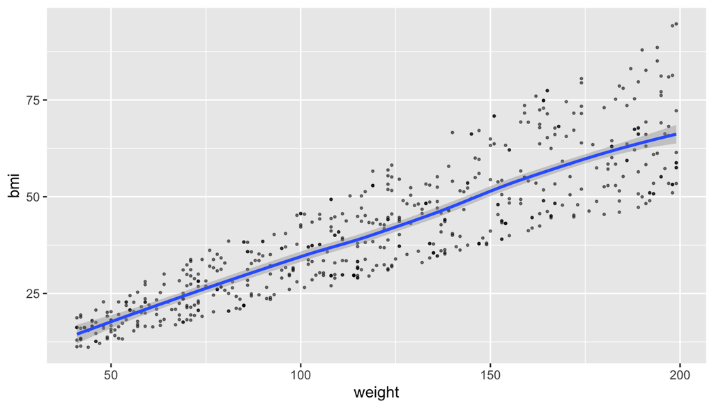

```r
ggplot(immuno_dataset$redcap_data$demographics, aes(x = weight, y = bmi)) +
  geom_point(size = 0.5, alpha = 0.5) +
  geom_smooth()
```

**Aesthetic Specifications in Plot vs. Layers**

Aesthetic mappings can be provided either in the initial `ggplot()` call, in individual layers, or through a combination of both approaches. When there’s only one layer in the plot, the method used to specify aesthetics doesn’t impact the result.

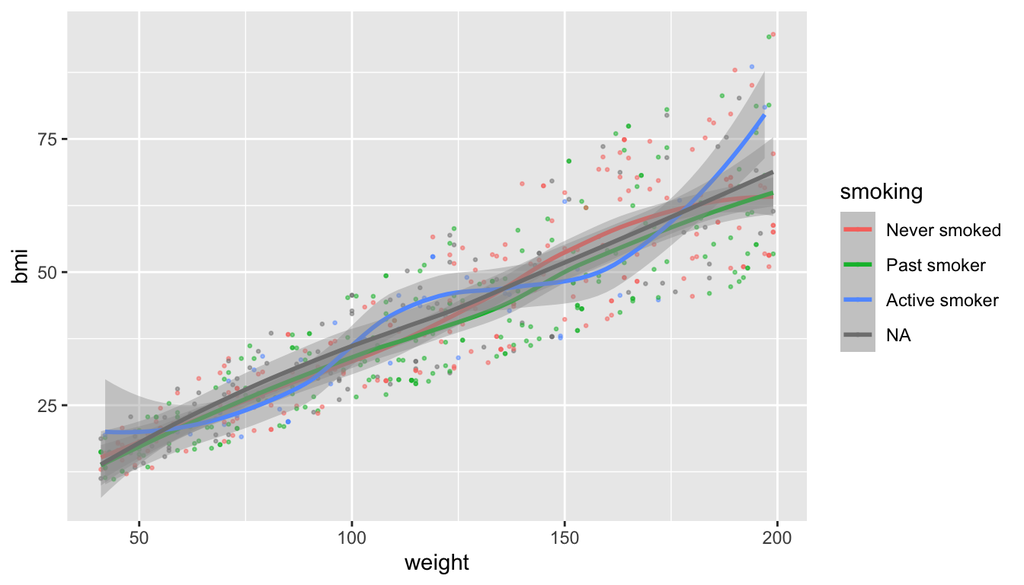

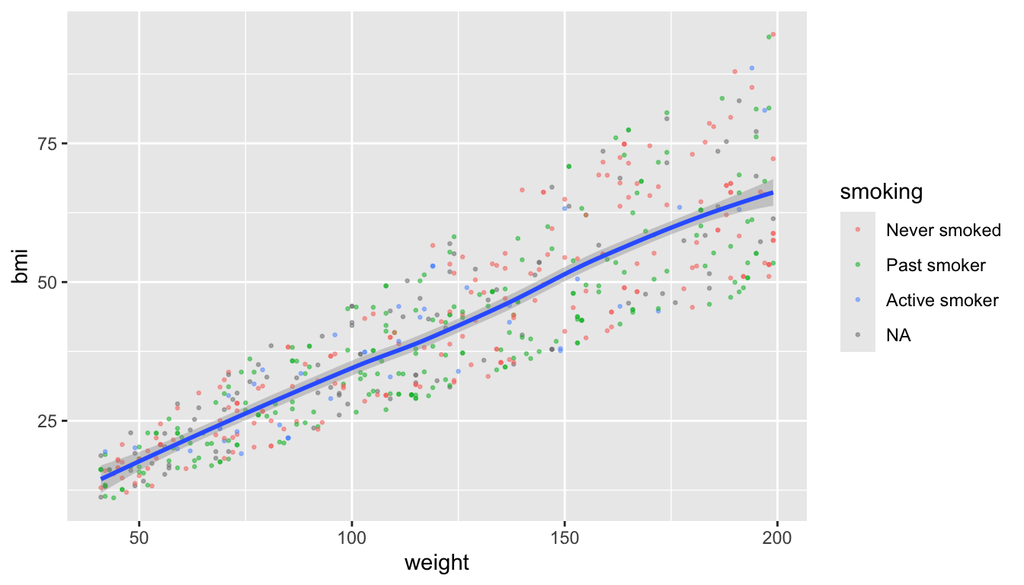

```r
# colour argument inside ggplot()
ggplot(immuno_dataset$redcap_data$demographics, aes(x = weight, y = bmi, colour = smoking)) +
  geom_point(size = 0.5, alpha = 0.5) +
  geom_smooth()
# colour argument inside geom_point()
ggplot(immuno_dataset$redcap_data$demographics, aes(x = weight, y = bmi)) +
  geom_point(aes(colour = smoking), size = 0.5, alpha = 0.5) +
  geom_smooth()
```

If we want to add colour only to the points and fit a regression line across all points, we could specify the colour inside `geom_point()` function (i.e., right plot).